# 빅데이터처리개론 기말과제

32152339 송준영

2020. 12. 15.

- 목차
1. Preprocessing
2. EDA
3. Classification Modling

# 작업 환경 구축

```r
setwd("C:/r/Reuters")
category <- read.csv('categories.csv')
dtmreut <- read.csv('dtmreut.csv',header = T)
txtreut <- read.csv('txtreut.csv')

library(tm)
library(stopwords)
library(textstem)
library(dplyr)
library(tidytext)
```

```r
library(wordcloud)
library(proxy)
library(corrplot)
library(rpart)
library(rpart.plot)
library(caret)
library(e1071)
library(class)
library(tidyverse)
library(randomForest)
library(xgboost)
set.seed(32152339)
```

# 1)Preprocessing

```r
sum(is.na(txtreut))#결측값이 없는 것을 확인할 수 있다.
```

```
## [1] 0
```

```r
dim(unique(txtreut))==dim(txtreut) #중복행이 없는 것을 확인할 수 있다.
```

```
## [1] TRUE TRUE
```

```r
summary(txtreut)
```

```
##        X
##  Min.   :    1
##  1st Qu.: 2723
##  Median : 5452
##  Mean   : 5434
##  3rd Qu.: 8161
##  Max.   :10788
##
##                                                                                                                                                                                                                                                                                                          …
##  FED SETS TWO BILLION DLR CUSTOMER REPURCHASE, FED SAYS FED SETS TWO BILLION DLR CUSTOMER REPURCHASE, FED SAYS                                                                                                                                                                                           …
##  SUMITA SAYS BANK WILL INTERVENE IF NECESSARY Bank of Japan Governor Satoshi Sumita said in a statement the central bank will intervene in foreign exchange markets to stabilise exchange rates if necessary in close cooperation with other major industrial nations. Sumita said the Bank will take ade…
##   Bundesbank sets 28-day securities repurchase tender at fixed 3.80 pct Bundesbank sets 28-day securities repurchase tender at fixed 3.80 pct                                                                                                                                                            …
##  AMERICAN GREETINGS CORP AGREA.O> 1ST QTR NET Period ended May 31 Shr 42 cts vs 53 cts Net 13,600,000 vs 17,100,000 Revs 263.3 mln vs 243.8 mln                                                                                                                                                          …
##  ANGLO AMERICAN AIVJ.J> YEAR TO DEC 31 Shr 516 cts vs 347 Final div 135 vs 125 making 190 vs 180 Pre-tax 133 mln rand vs 137 mln Net 260 mln vs 172 mln Tax 76 mln vs 42 mln Att to outside shareholders 96 mln vs 53 mln Pref div 1 mln vs same Turnover 3.14 billion vs 2.56 billion Div pay May 8, reg…
##  BALDRIGE PREDICTS END OF U.S.-JAPAN TRADE DISPUTE The United States and Japan will soon settle their trade dispute over semiconductors, U.S. Commerce secretary Malcolm Baldrige said on television. Baldrige, referring to the U.S.-Japan trade agreement on semiconductors, said: "Their government wa…
##  (Other)                                                                                                                                                                                                                                                                                                 …
```

```r
#소문자화
txtreut$x<-sapply(txtreut$x,tolower)

#숫자제거
for (i in 1:nrow(txtreut)){
  txtreut$x[i]<-gsub(txtreut$x[i],pattern = "\\d+",replacement = "")
}

#특수문자 제거
txtreut$x<-sapply(txtreut$x,removePunctuation)

#토크나이징
tokenizer <- function(x)
  unlist(strsplit(as.character(x), " "))
txtreut$x_tk<-sapply(txtreut$x, tokenizer)

#불용어 제거
for (i in 1:nrow(txtreut)){
  txtreut$x_tk[i]<-list(txtreut$x_tk[i][[1]][! txtreut$x_tk[i][[1]] %in% c(stopwords(),"")])
}

#어근으로 변환
for (i in 1:nrow(txtreut)){
  txtreut$x_tk[i]<-list(lemmatize_strings(txtreut$x_tk[i][[1]]))
}

#라벨 조인
txtreut<-left_join(txtreut,category,by='X')

head(txtreut,3)
```

```
##    X
## 1  1
## 2  6
## 3 10
##                                                                                                                                                                                                                                                                                                          …
## 1 asian exporters fear damage from usjapan rift mounting trade friction between the us and japan has raised fears among many of asias exporting nations that the row could inflict farreaching economic damage businessmen and officials said they told reuter correspondents in asian capitals a us move…
## 2                                                                                                                                                                                                                                                                                                        …
## 3                                                                                                                                                                                                                                                                                                   sumit…
##                                                                                                                                                                                                                                                                                                          …
## 1 asian, exporter, fear, damage, usjapan, rift, mount, trade, friction, us, japan, raise, fear, among, many, asias, export, nation, row, inflict, farreaching, economic, damage, businessman, official, say, tell, reuter, correspondent, asian, capital, us, move, japan, may, boost, protectionist, sen…
## 2                                                                                                                                                                                                                                                                                                        …
## 3                                                                                                                                                                                                                                                                                                        …
##   category
## 1    trade
## 2    sugar
## 3      acq
```

- txtreut 결측값, 중복값 확인
- 소문자로 변환
- 숫자 제거
- puntuation 제거
- Tokenizing
- stopwords 제거
- lemmatization
- label과 join  
  => 이러한 전처리를 통해서 dtm을 생성했다고 가정하고, 이 이후 dtm은 제공된 dtmreut을 사용한다.

# 2) EDA

```r
dtmreut<-left_join(dtmreut,category,by='X')

#클래스별 빈도 확인
table(dtmreut$category)
```

```
##
##      acq   coffee    crude     earn interest money.fx     ship    sugar
##     2245      112      363     3885      270      304      143      141
##    trade
##      446
```

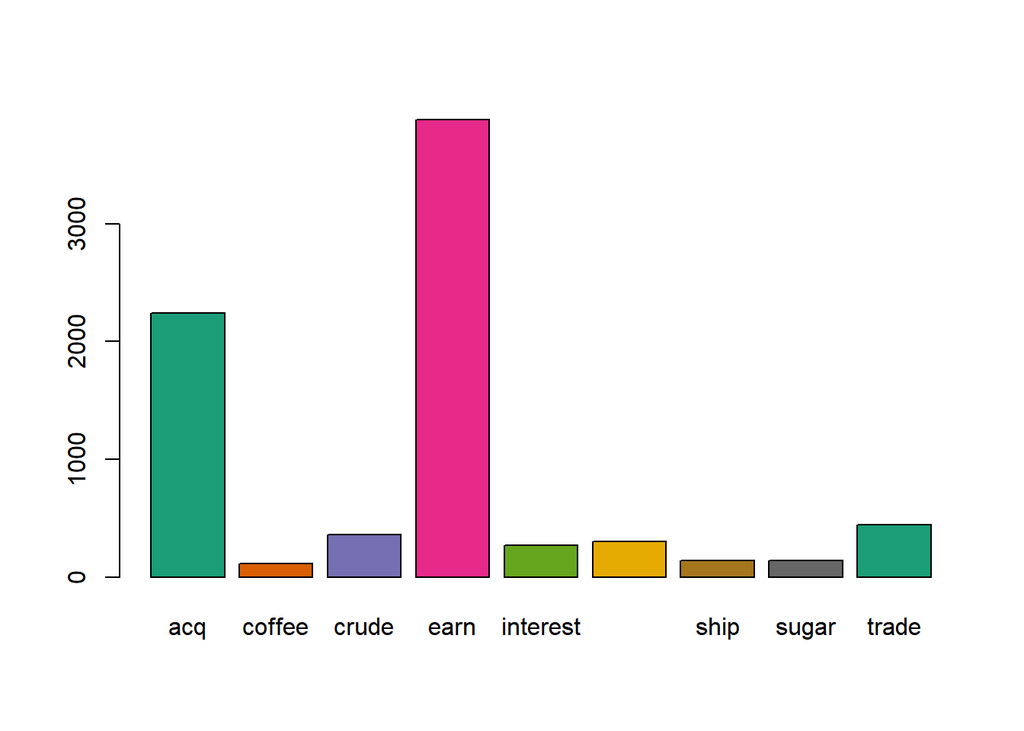

```r
barplot(table(dtmreut$category),col = brewer.pal(8, "Dark2"))
```

```r
#클래스별
acq<-dtmreut %>% filter(category=="acq") %>% select(-category)
coffee<-dtmreut %>% filter(category=="coffee") %>% select(-category)
crude<-dtmreut %>% filter(category=="crude") %>% select(-category)
earn<-dtmreut %>% filter(category=="earn") %>% select(-category)
interest<-dtmreut %>% filter(category=="interest") %>% select(-category)
money.fx<-dtmreut %>% filter(category=="money.fx") %>% select(-category)
ship<-dtmreut %>% filter(category=="ship") %>% select(-category)
sugar<-dtmreut %>% filter(category=="sugar") %>% select(-category)
trade<-dtmreut %>% filter(category=="trade") %>% select(-category)

#클래스별 열별 합 데이터 생성
acq_cnt<-colSums(acq%>%select(-X))
coffee_cnt<-colSums(coffee%>%select(-X))
crude_cnt<-colSums(crude%>%select(-X))
earn_cnt<-colSums(earn%>%select(-X))
interest_cnt<-colSums(interest%>%select(-X))
money.fx_cnt<-colSums(money.fx%>%select(-X))
ship_cnt<-colSums(ship%>%select(-X))
sugar_cnt<-colSums(sugar%>%select(-X))
trade_cnt<-colSums(trade%>%select(-X))

#클래스별 고빈도 단어 확인.
head(sort(acq_cnt,decreasing = T))
```

```
##     say   share company    dlrs     mln     inc
##    7050    3219    2634    2627    2125    2016
```

```r
head(sort(coffee_cnt,decreasing = T))
```

```
##   coffee      say    quota   export producer      ico
##      556      470      302      249      187      176
```

```r
head(sort(crude_cnt,decreasing = T))
```

```
##    say    oil  price  crude   opec barrel
##   1570   1518    704    529    506    490
```

```r
head(sort(earn_cnt,decreasing = T))
```

```
##    vs   mln   cts   net  dlrs  loss
## 14127 11274  7908  6593  5892  5192
```

```r
head(sort(interest_cnt,decreasing = T))
```

```
##     rate      pct     bank      say      cut interest
##     1006      832      728      708      247      237
```

```r
head(sort(money.fx_cnt,decreasing = T))
```

```
##      say     bank   market currency     rate   dollar
##     1111      612      439      381      358      357
```

```r
head(sort(ship_cnt,decreasing = T))
```

```
## billion    dlrs     pct    rise    bank     say
##     487     457     386     317     289     276
```

```r
head(sort(sugar_cnt,decreasing = T))
```

```
##    say   ship   port     us strike   gulf
##    469    234    147    122    121    105
```

```r
head(sort(trade_cnt,decreasing = T))
```

```
##   say trade    us japan  year sugar
##  1951  1673  1045   593   584   581
```

- earn 클래스가 가장 고빈도로 관찰됨.
- raw DTM을 클래스 별로 분리함.
- 추후 EDA에 활용하기 위해 클래스별로 분리한 DTM을 열별로 합함.
- 클래스별 고빈도 단어 확인.

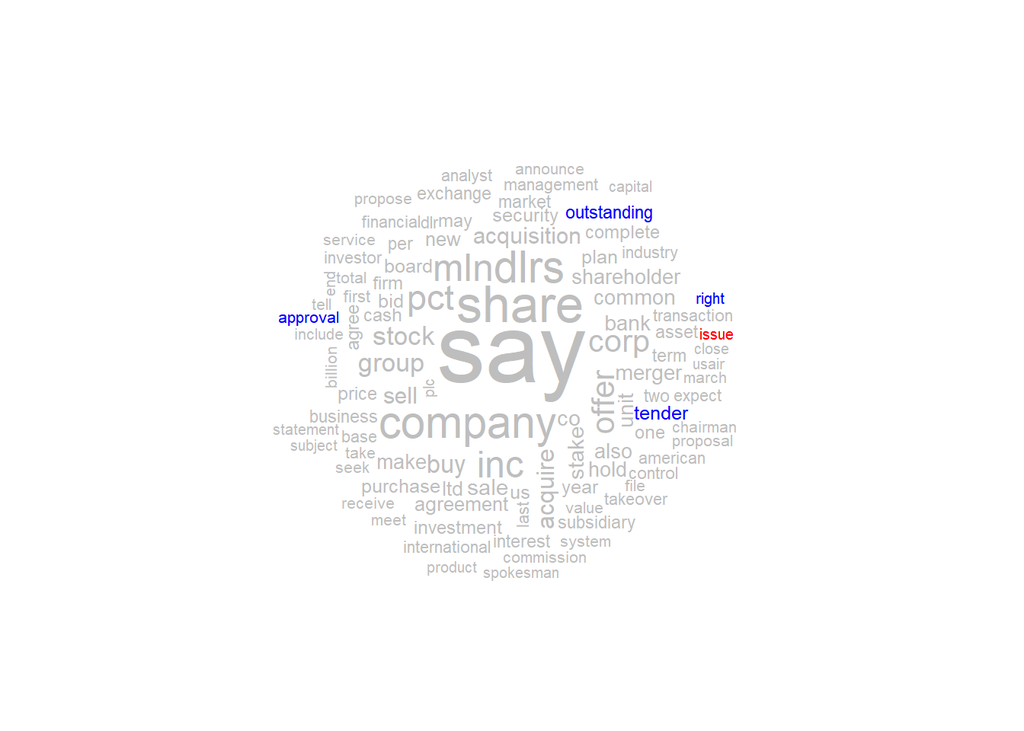

```r
#감성분석 기반 워드클라우드
bingsent <- get_sentiments("bing")
bingpos <- bingsent[bingsent$sentiment=='positive',]
bingneg <- bingsent[bingsent$sentiment=='negative',]

#사용자 함수 정의
sent_wc<-function(x){
  wordcolor <- rep("grey",length(x))
  wordcolor[names(x) %in% bingpos$word] = "blue"
  wordcolor[names(x) %in% bingneg$word] = "red"
  wordcloud(names(x),x,max.words = 100,colors = wordcolor,random.order = F,ordered.colors = T)
}

#클래스별 감성분석 워드클라우드
sent_wc(acq_cnt)
```

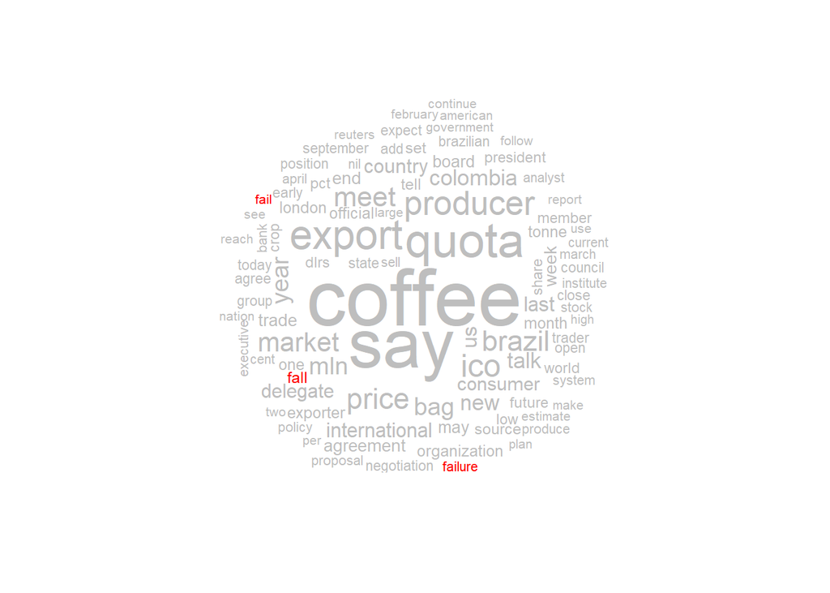

```r
sent_wc(coffee_cnt)
```

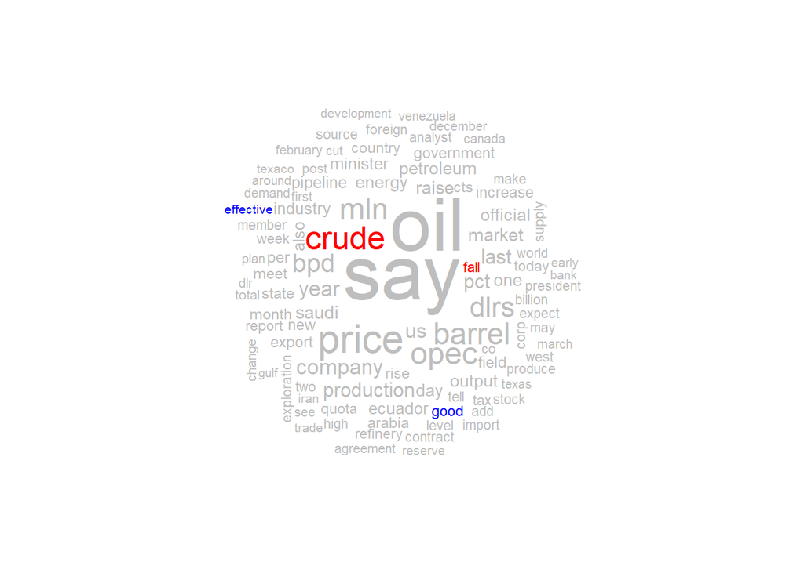

```r
sent_wc(crude_cnt)
```

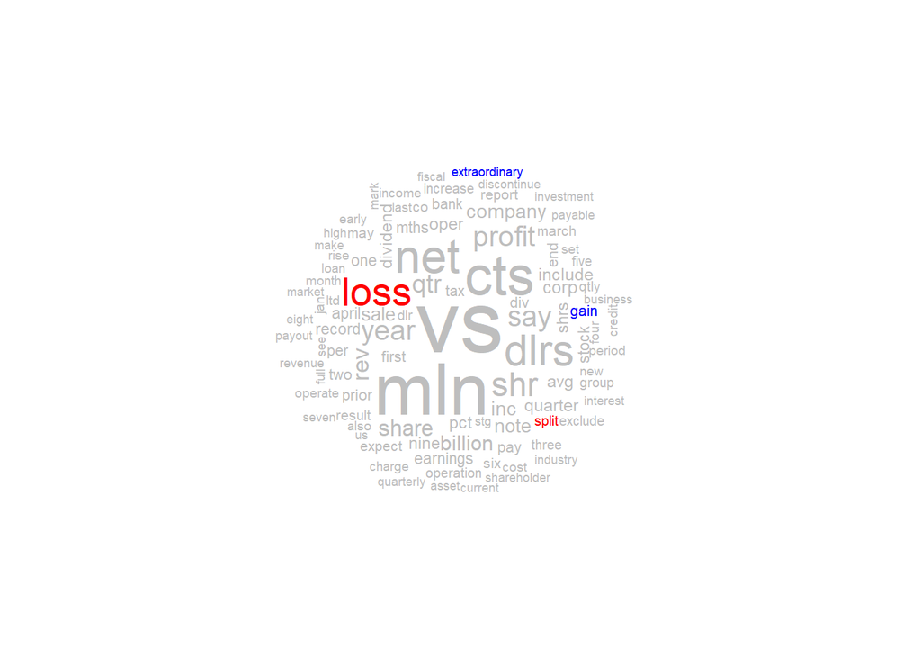

```r
sent_wc(earn_cnt)
```

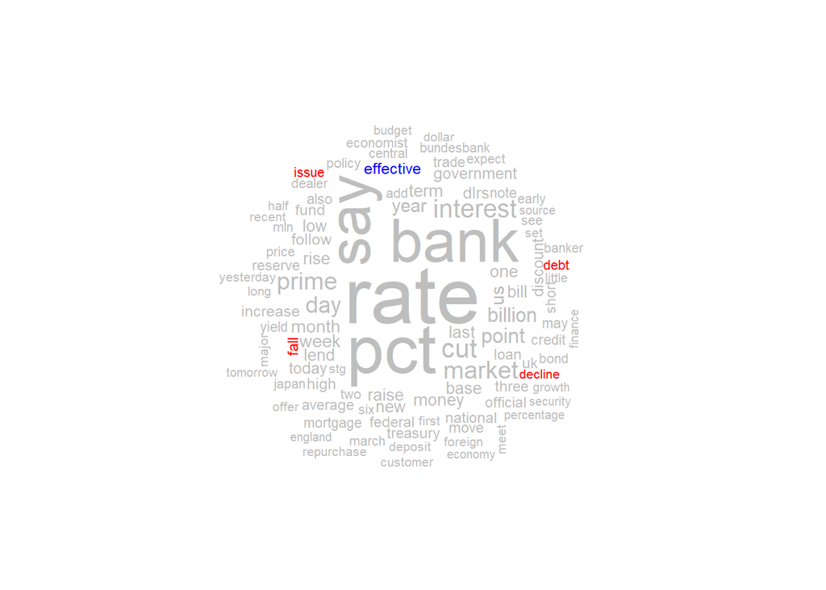

```r
sent_wc(interest_cnt)
```

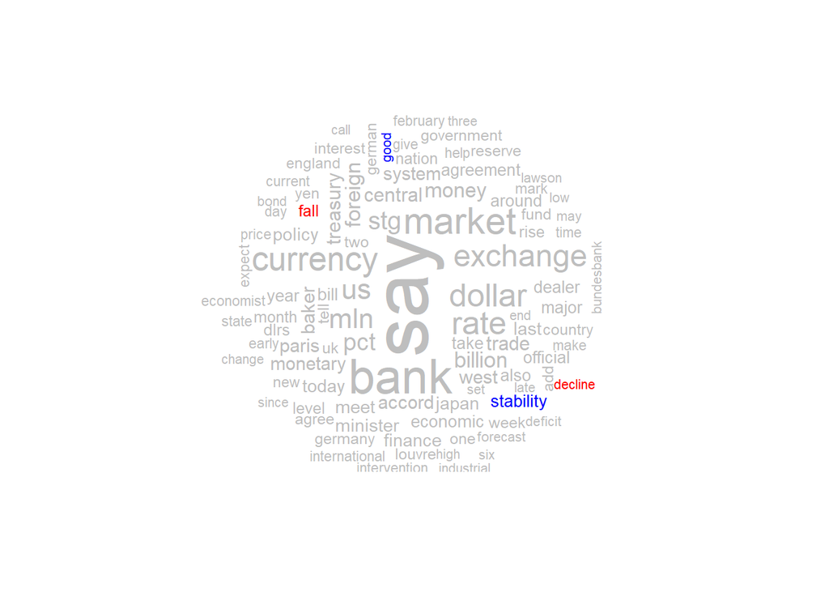

```r
sent_wc(money.fx_cnt)
```

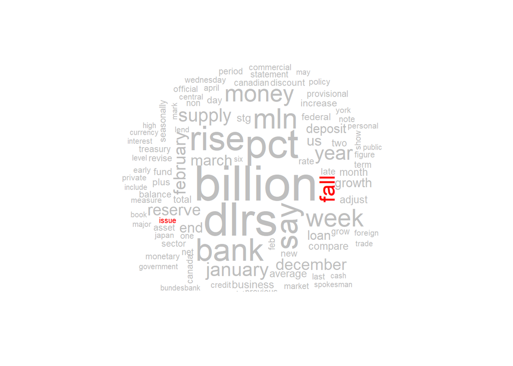

```r
sent_wc(ship_cnt)
```

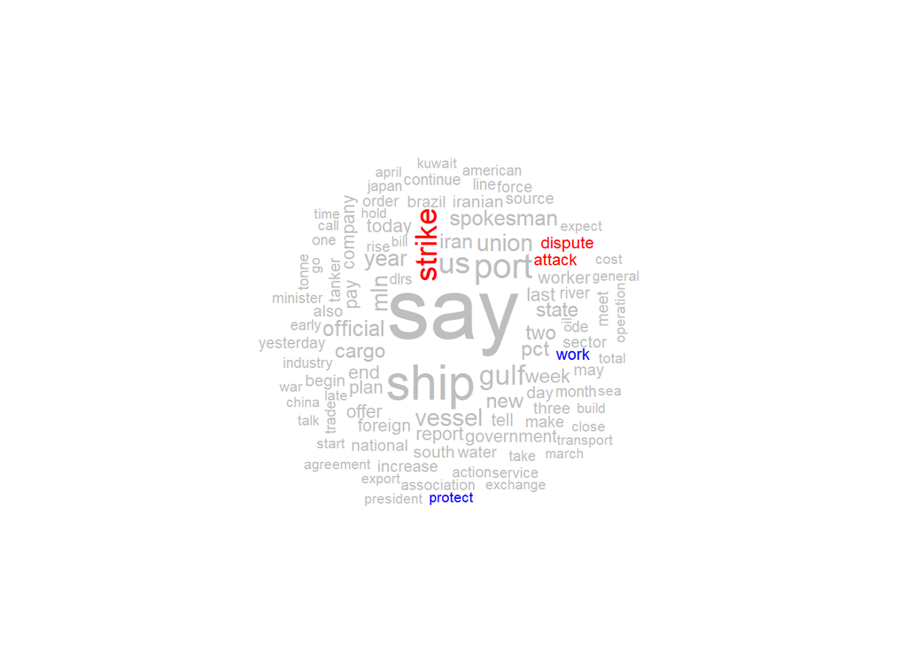

```r
sent_wc(sugar_cnt)
```

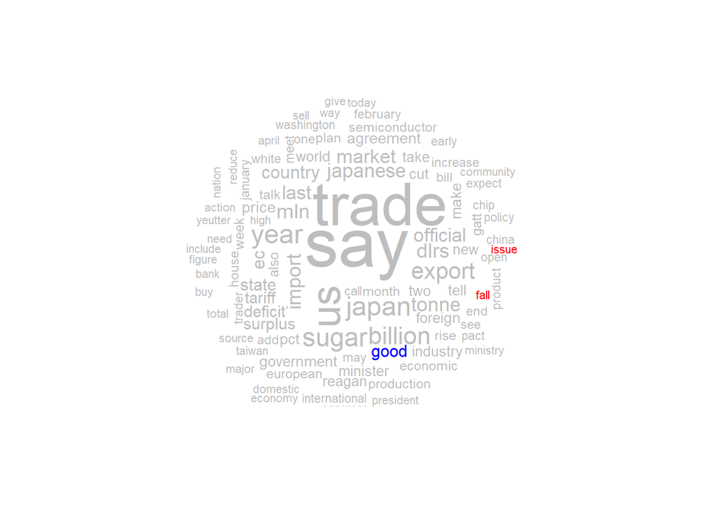

```r
sent_wc(trade_cnt)
```

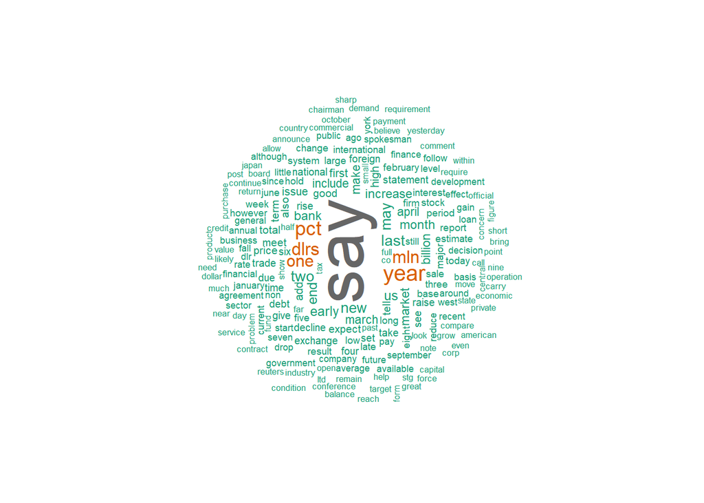

```r
#다중 클래스 워드클라우드

#모든 클래스를 합한 데이터셋 생성
mat<-cbind(as.matrix(acq_cnt),as.matrix(coffee_cnt),as.matrix(crude_cnt),
           as.matrix(earn_cnt),as.matrix(interest_cnt),as.matrix(money.fx_cnt),
           as.matrix(ship_cnt),as.matrix(sugar_cnt),as.matrix(trade_cnt))
colnames(mat)<-names(table(dtmreut$category))


#다중클래스 집계 데이터의 단어별 min, max, mean 을 기준으로 워드클라우드 시각화
commonality.cloud(mat,min,200,random.order=F,colors = brewer.pal(8, "Dark2")) #단어의 최소값을 기준으로 시각화
```

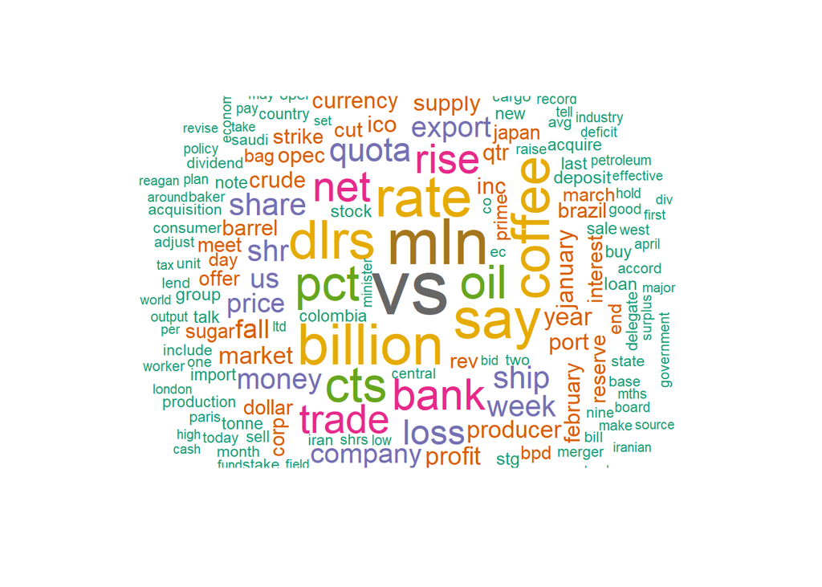

```r
commonality.cloud(mat,max,200,random.order=F,colors = brewer.pal(8, "Dark2")) #단어의 최대값을 기준으로 시각화
```

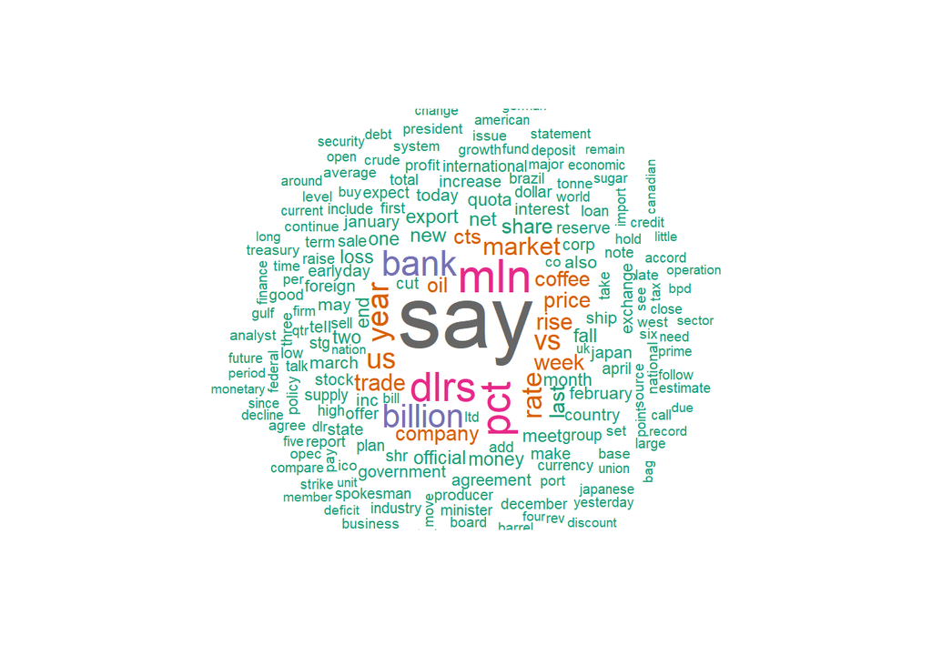

```r
commonality.cloud(mat,mean,200,random.order=F,colors = brewer.pal(8, "Dark2"))#단어의 평균값을 기준으로 시각화
```

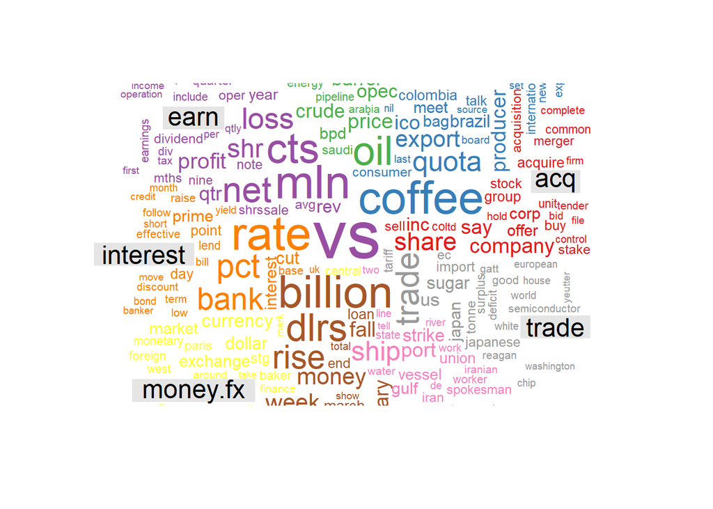

```r
#비교 워드클라우드 시각화
comparison.cloud(mat,max.words = 300,colors = brewer.pal(9, "Set1"),random.order = F,title.size=1.5)
```

- 모든 클래스를 비교하기 위한 워드클라우드를 하기 위해 모든 클래스를 한 데이터셋 내에 합함.
- 단어별 최소값을 기준으로 워드클라우드를 한 결과, say가 압도적으로 크게 관찰되며 year, pct 등이 그 뒤를 이음.
- 단어별 최대값을 기준으로 워드클라우드를 한 결과, vs가 가장 고빈도로 관찰되며 say, billion, mln 등이 그 뒤를 이음.
- 단어별 평균값을 기준으로 워드클라우드를 한 결과, say가 가장 크게 관찰되며 mln, dlrs 등이 그 뒤를 이음.
- 모든 클래스별를 한 워드클라우드 안에 비교 분석하기 위하여, 각각의 색으로 표현한 wordcloud로 나타내었고, VS가 모든 클래스의 단어들 중 가장 고빈도로 예상됨.

```r
#클래스별 코사인 유사도
cossim<-function(x,y){
  sum(x*y)/(sqrt(sum(x*x))*sqrt(sum(y*y)))
}
cossim(acq_cnt,coffee_cnt)
```

```
## [1] 0.4678211
```

```r
mat_dtm<-1-as.matrix(dist(t(mat), method = "cosine"))
mat_dtm
```

```
##                acq    coffee     crude      earn  interest  money.fx      ship
## acq      1.0000000 0.4678211 0.6013447 0.3807447 0.4723570 0.6067471 0.4565418
## coffee   0.4678211 1.0000000 0.4819650 0.1881788 0.3361505 0.4962958 0.2803045
## crude    0.6013447 0.4819650 1.0000000 0.2829776 0.4102503 0.5533082 0.3953427
## earn     0.3807447 0.1881788 0.2829776 1.0000000 0.1715483 0.2454997 0.3560498
## interest 0.4723570 0.3361505 0.4102503 0.1715483 1.0000000 0.7189876 0.5589320
## money.fx 0.6067471 0.4962958 0.5533082 0.2454997 0.7189876 1.0000000 0.5433504
## ship     0.4565418 0.2803045 0.3953427 0.3560498 0.5589320 0.5433504 1.0000000
## sugar    0.6385834 0.4982450 0.5954869 0.2272497 0.4461677 0.6229166 0.3657268
## trade    0.5707105 0.5446702 0.5686437 0.2380479 0.4520215 0.6767440 0.4420579
##              sugar     trade
## acq      0.6385834 0.5707105
## coffee   0.4982450 0.5446702
## crude    0.5954869 0.5686437
## earn     0.2272497 0.2380479
## interest 0.4461677 0.4520215
## money.fx 0.6229166 0.6767440
## ship     0.3657268 0.4420579
## sugar    1.0000000 0.6520801
## trade    0.6520801 1.0000000
```

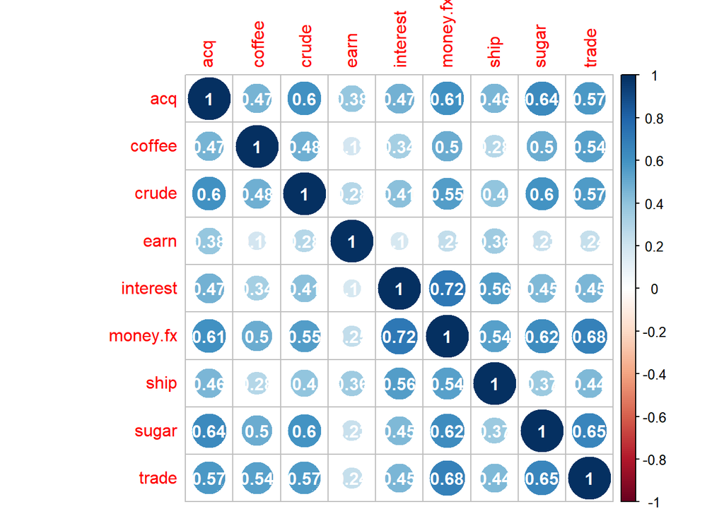

```r
corrplot(mat_dtm,addCoef.col = "white")
```

- 클래스별 코사인 유사도를 확인하기 위하여 함수를 정의.
- dist함수의 “cosine” method를 사용하여 모든 클래스끼리 코사인 유사도를 확인.
- interset와 money.fx가 0.72로 높은 유사도를 보임.
- 대체로 earn 클래스가 타 변수와 유사도가 없는 것을 확인.

```r
#클래스별 DTM을 정의.
DTM<-t(mat)

# tf-idf 함수 정의
tfidf <- function(x) {
  tf <- ifelse(x>0, 1+log(x), 0)
  df <- colSums(x>0)
  idf <- log(dim(x)[1]/df)
  tfidf <- t(t(tf)*idf)
  tfidf
}

# tf-idf 적용
class_tfidf_DTM<-tfidf(DTM)

# 의미없는 단어를 추출
remove_word_list<-names(colSums(class_tfidf_DTM)[colSums(class_tfidf_DTM)==0])
length(remove_word_list)
```

```
## [1] 385
```

```r
remove_word_list
```

```
##   [1] "account"       "act"           "action"        "activity"
##   [5] "add"           "additional"    "adjustment"    "affect"
##   [9] "ago"           "agree"         "agreement"     "ahead"
##  [13] "aim"           "allow"         "almost"        "along"
##  [17] "already"       "also"          "although"      "american"
##  [21] "amount"        "announce"      "annual"        "appear"
##  [25] "april"         "around"        "august"        "authority"
##  [29] "available"     "average"       "back"          "balance"
##  [33] "bank"          "base"          "basis"         "become"
##  [37] "believe"       "bill"          "billion"       "board"
##  [41] "book"          "boost"         "bring"         "build"
##  [45] NA              "business"      "call"          "canada"
##  [49] "capital"       "carry"         "cash"          "cause"
##  [53] "central"       "certain"       "chairman"      "change"
##  [57] "clear"         "close"         "co"            "come"
```

[output cut: 82 more lines]

- tf-idf를 클래스별 DTM에 적용.
- tf-idf 가중치가 0인 단어를 저장하고 추후 분석에 활용.

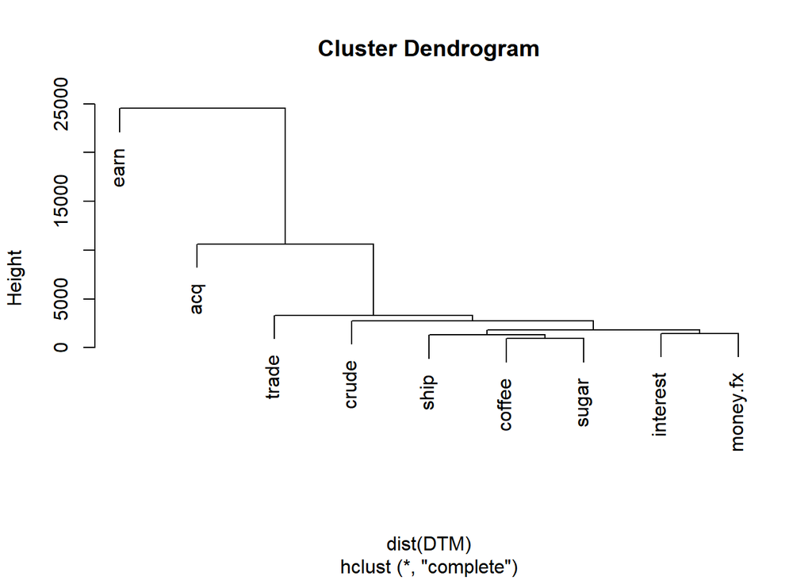

```r
#class별로 집계한 데이터셋 클러스터링
plot(hclust(dist(DTM)))
```

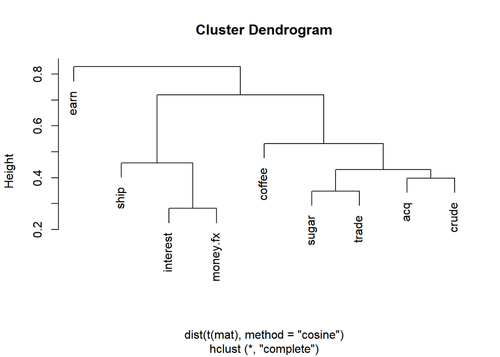

```r
#class별로 집계한 데이터셋 코사인 유사도 기반 클러스터링
plot(hclust(dist(t(mat), method = "cosine")))
```

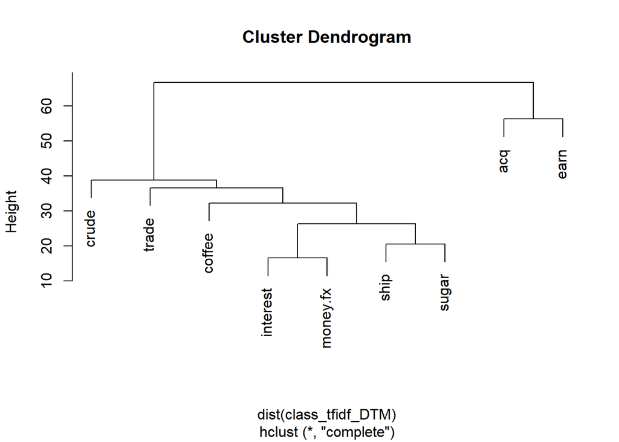

```r
 #class별 tfidf 데이터셋 클러스터링
plot(hclust(dist(class_tfidf_DTM)))
```

- euclidean distance 기반 계층적 군집분석
- 전체적으로 earn class가 가장 cluster가 나중에 됨을 볼 수 있음.
- 코사인 유사도의 결과와 마찬가지로 earn class가 타 class와 제일 잘 구분된다는 의미로 해석됨.

# 3) Classification Modeling

```r
options(scipen=100);#자연상수 출력방지

all_DTM<- dtmreut %>% select(-c(X))
removed_DTM<-dtmreut[, !(names(dtmreut) %in% c(remove_word_list,'X'))]
tfidf_DTM<-cbind(as.data.frame(tfidf(as.matrix(dtmreut %>% select(-c(X,category))))),category=category$category)

dim(all_DTM)
```

```
## [1] 7909 1079
```

```r
dim(removed_DTM)
```

```
## [1] 7909  697
```

```r
dim(tfidf_DTM)
```

```
## [1] 7909 1079
```

- 비교분석하기 위해 3가지 데이터셋 생성
- all_DTM : 원 데이터셋
- removed_DTM : 클래스별 DTM에서 추출한 필요없는 단어를 제거한 DTM
- tfidf_DTM : 원 DTM에 tfidf 적용

### decision tree

[figure not shown]

```r
ctrl<-rpart.control(minsplit = 5,cp=0.0001,xval=5) #각 노드에 5개 이상 있으면 분할하기
fit_tree<-rpart(category~.,data=all_DTM,method='class',control=ctrl)
prp(fit_tree,cex = .5,box.palette = "auto", roundint=FALSE)
```

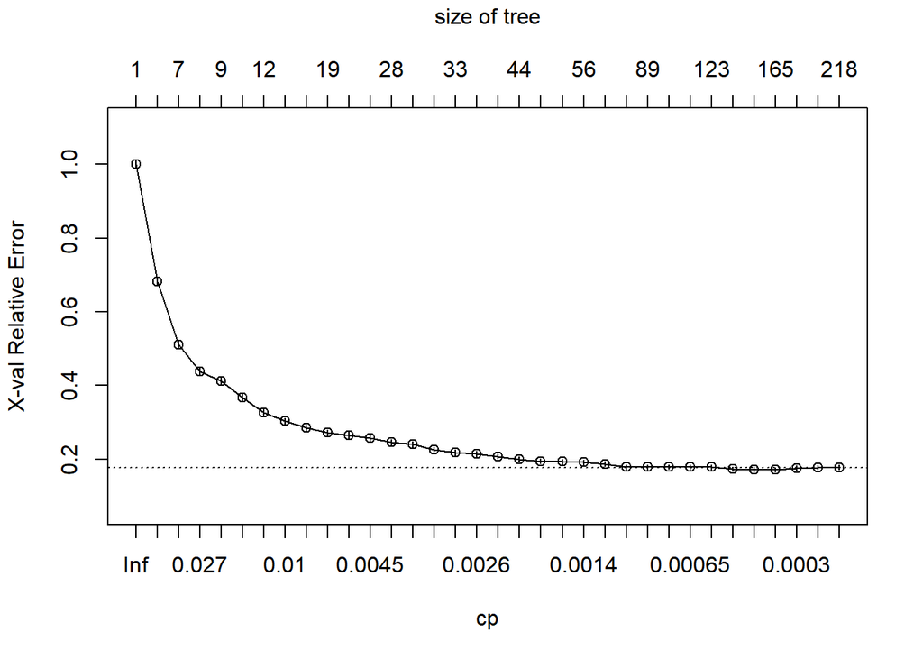

```r
plotcp(fit_tree)#그림상 cp를 0.001로 제한하여 가지치기를 하면 될것으로 보임
```

```r
printcp(fit_tree) #각 분할별 cp값 출력
```

```
##
## Classification tree:
## rpart(formula = category ~ ., data = all_DTM, method = "class",
##     control = ctrl)
##
## Variables actually used in tree construction:
##   [1] able          account       acquire       acquisition   ag
##   [6] ago           agreement     also          among         amount
##  [11] analyst       annual        approach      approve       association
##  [16] bank          barrel        begin         bid           bill
##  [21] billion       board         bonus         bpd           business
##  [26] buy           buyer         california    canadian      cause
##  [31] central       charge        china         co            coal
##  [36] coffee        commission    company       continue      corp
##  [41] cost          credit        crude         cts           currency
```

[output cut: 60 more lines]

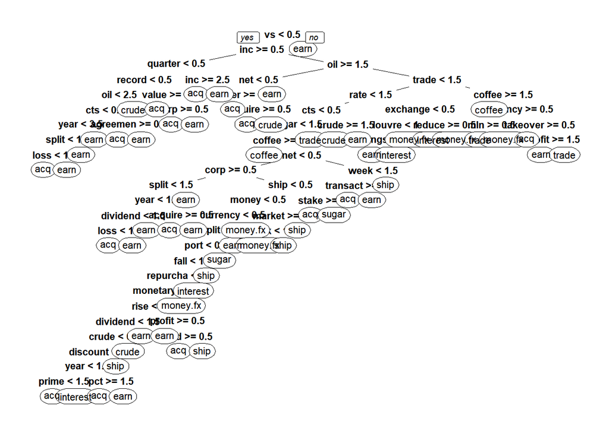

```r
pruned<-prune(fit_tree,cp=0.001) #cp를 0.01로 가지치기
prp(pruned,cex=.7,box.palette =0, roundint=FALSE)
```

- minsplit을 5로 설정함으로써 노드당 최소데이터 수를 5로 함.
- 가지치기를 하기 위하여 복잡도(cp)를 초기에 0.0001로 설정.
- xval을 5로 설정함으로써 5 fold cross validation 설정.
- 복잡도그림을 통해 찾은 복잡도(0.001)로 가지치기

[figure not shown]

```r
#tfidf dtm
ctrl<-rpart.control(minsplit = 5,cp=0.0001,xval=5)
fit_tree<-rpart(category~.,data=tfidf_DTM,method='class',control=ctrl)
prp(fit_tree,cex = .5,box.palette = 0, roundint=FALSE)
```

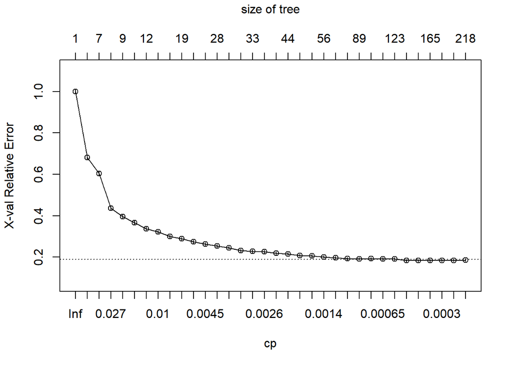

```r
plotcp(fit_tree)#변수를 제거한 DTM역시 그림상 cp를 0.001로 제한하여 가지치기를 하면 될것으로 보임
```

```r
printcp(fit_tree) #자연상수 출력 방지 및 각 분할별 cp값 출력
```

```
##
## Classification tree:
## rpart(formula = category ~ ., data = tfidf_DTM, method = "class",
##     control = ctrl)
##
## Variables actually used in tree construction:
##   [1] able          account       acquire       acquisition   ag
##   [6] ago           agreement     also          among         amount
##  [11] analyst       annual        approach      approve       association
##  [16] bank          barrel        begin         bid           bill
##  [21] billion       board         bonus         bpd           business
##  [26] buy           buyer         california    canadian      cause
##  [31] central       charge        china         co            coal
##  [36] coffee        commission    company       continue      corp
##  [41] cost          credit        crude         cts           currency
```

[output cut: 60 more lines]

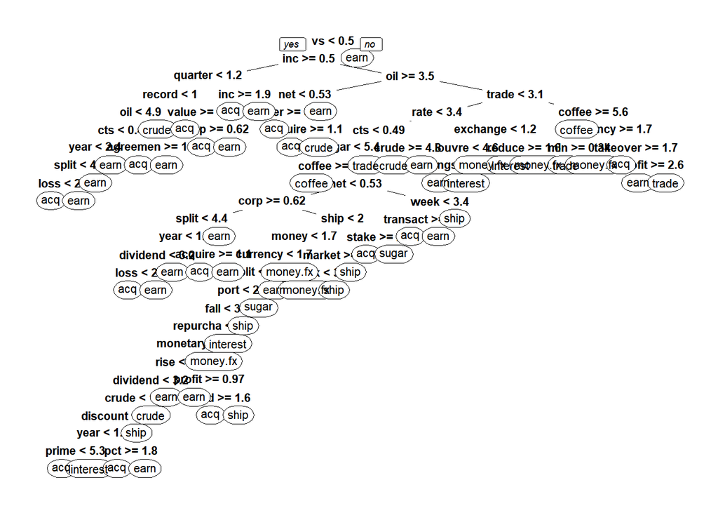

```r
pruned<-prune(fit_tree,cp=0.001)
prp(pruned,cex=.7,box.palette =0, roundint=FALSE)
```

- all_DTM과 같은 방법으로 의사결정나무를 훈련하고 최적의 CP를 구함.

[figure not shown]

```r
#removed dtm
ctrl<-rpart.control(minsplit = 5,cp=0.0001,xval=5)
fit_tree<-rpart(category~.,data=removed_DTM,method='class',control=ctrl)
prp(fit_tree,cex = .5,box.palette = 0, roundint=FALSE)
```

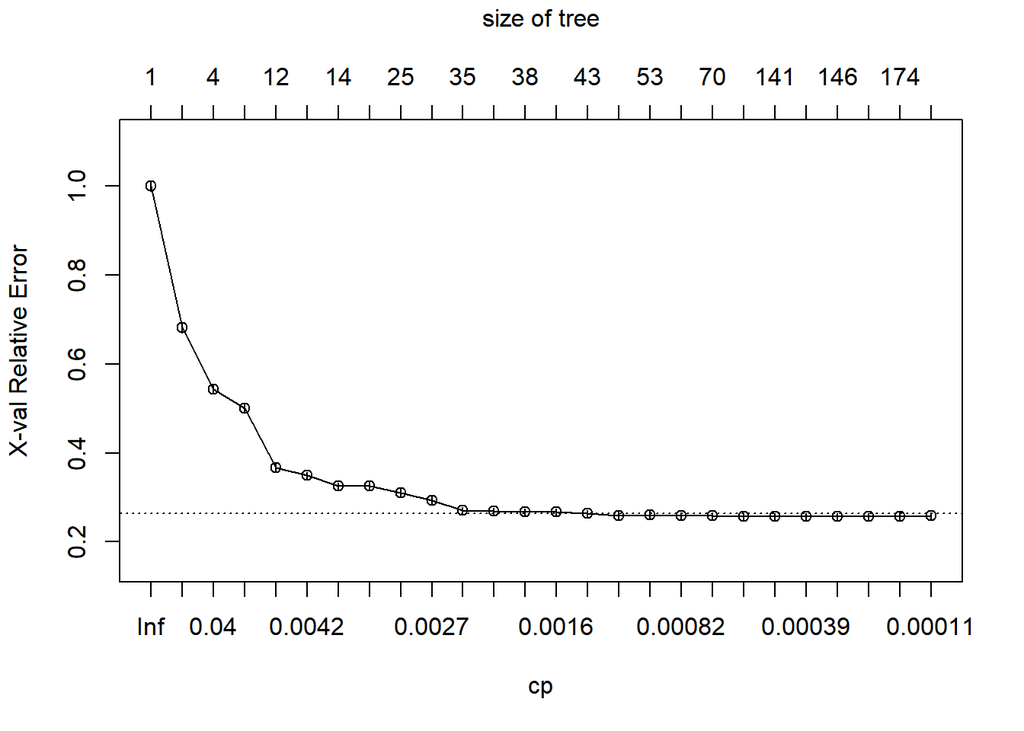

```r
plotcp(fit_tree)#변수를 제거한 DTM역시 그림상 cp를 0.001로 제한하여 가지치기를 하면 될것으로 보임
```

```r
printcp(fit_tree) #자연상수 출력 방지 및 각 분할별 cp값 출력
```

```
##
## Classification tree:
## rpart(formula = category ~ ., data = removed_DTM, method = "class",
##     control = ctrl)
##
## Variables actually used in tree construction:
##   [1] able         accept       acquire      acquisition  african
##   [6] another      asset        assistance   baker        band
##  [11] barrel       benefit      bid          bond         bonus
##  [16] bp           british      budget       bundesbank   buy
##  [21] canadian     chicago      chip         coffee       common
##  [26] complete     cost         crude        cts          customer
##  [31] deal         deficit      deposit      director     discussion
##  [36] dispute      distribution dividend     earnings     economist
##  [41] energy       england      european     expense      express
```

[output cut: 47 more lines]

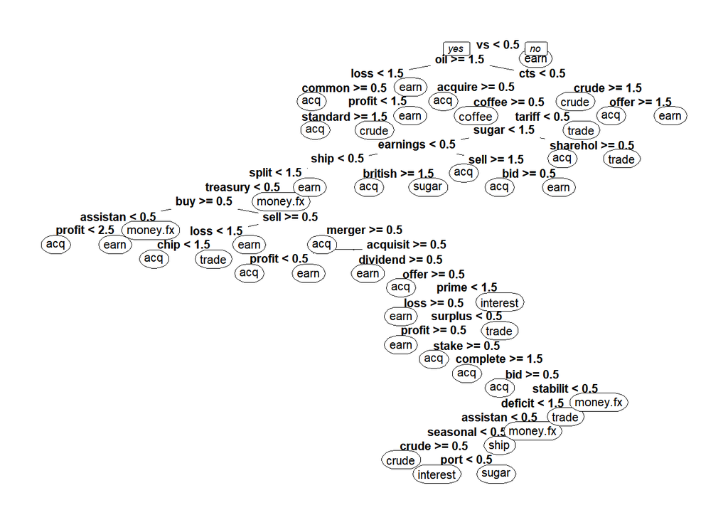

```r
pruned<-prune(fit_tree,cp=0.001)
prp(pruned,cex=.7,box.palette =0, roundint=FALSE)
```

- all_DTM과 같은 방법으로 의사결정나무를 훈련하고 최적의 CP를 구함.

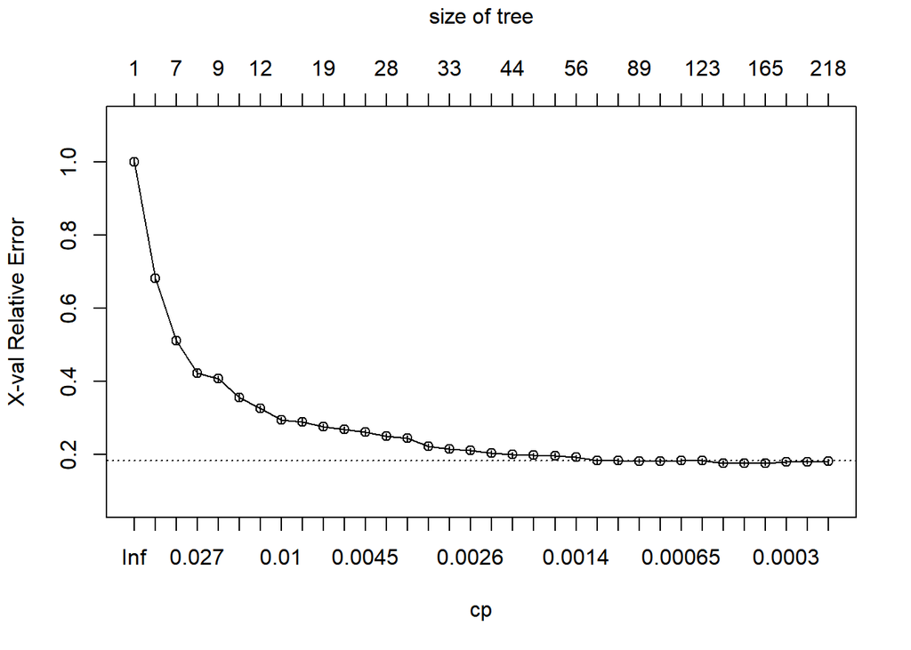

```r
#의사결정나무의 복잡도 그래프를 출력하는 함수 정의
dt_cp_plot<-function(dtm){
  ctrl<-rpart.control(minsplit = 5,cp=0.0001,xval=5)
  fit_tree<-rpart(category~.,data=dtm,method='class',control=ctrl)
  #prp(fit_tree,cex = .5,box.palette = "auto", roundint=FALSE)
  plotcp(fit_tree)#그림상 cp를 0.001로 제한하여 가지치기를 하면 될것으로 보임
}

dt_cp_plot(all_DTM) #0.001에서 가지치기 적용하면 좋을 것 같음
```

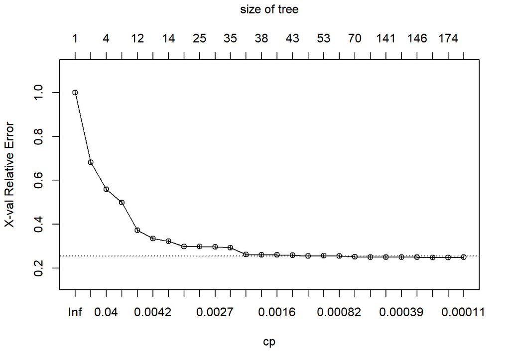

```r
dt_cp_plot(removed_DTM) #0.001에서 가지치기 적용하면 좋을 것 같음
```

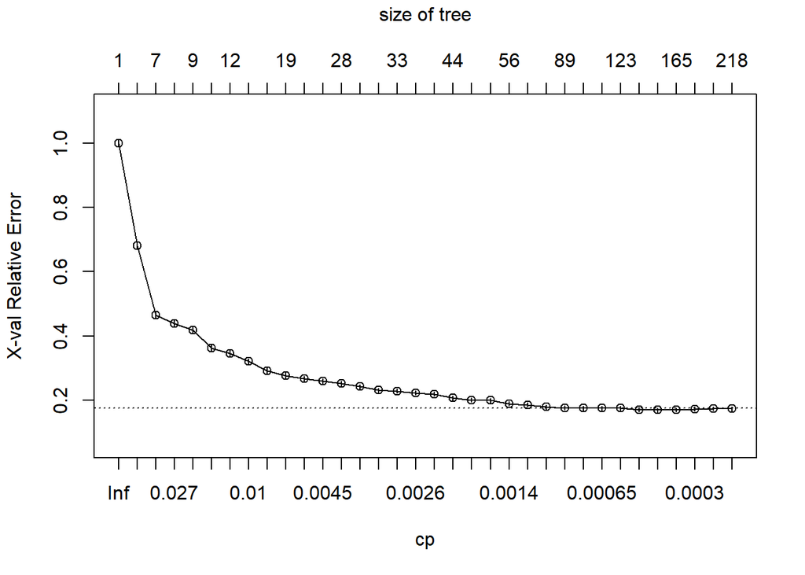

```r
dt_cp_plot(tfidf_DTM) #0.001에서 가지치기 적용하면 좋을 것 같음
```

- 의사결정나무의 복잡도 그래프를 출력하는함수를 정의하여 추후 가지치기에 활용.
- 세 데이터셋 모두 CP가 0.001이 적절할 것 처럼 보임.

```r
#k-fold 교차검증 의사결정나무 함수 정의
dt_cv<-function(dtm,cp=0.001,k=5){
  cv_index<-createFolds(dtm$category,k=k)
  acc<-c()
  for (i in 1:k){
    ctrl<-rpart.control(minsplit = 5,cp=cp,xval=5)
    fit_tree<-rpart(category~.,data=dtm[unlist(cv_index[-i]),],control=ctrl)
    pred <- predict(fit_tree, subset(dtm[unlist(cv_index[i]),],select = -category), type = 'class')
    acc[i] <- confusionMatrix(as.factor(as.character(pred)),as.factor(category[unlist(cv_index[i]),]$category))[[3]][1]
  }
  mean(acc)
}

#(all_DTM, removed_DTM, tfidf_DTM) 데이터셋별 정확도 확인
dt_cv(all_DTM,cp=0.001) #dt_cp_plot을 통해 정한 cp 적용
```

```
## [1] 0.9015064
```

```r
dt_cv(removed_DTM,cp=0.001) #dt_cp_plot을 통해 정한 cp 적용
```

```
## [1] 0.8720378
```

```r
dt_cv(tfidf_DTM,cp=0.001) #dt_cp_plot을 통해 정한 cp 적용
```

```
## [1] 0.9046671
```

- K-fold를 활용한 의사결정나무를 훈련시키기위해 함수를 정의함.
- (all_DTM, removed_DTM, tfidf_DTM) 데이터셋별 정확도 확인
- all_DTM ≒ tfidf_DTM > removed_DTM
- 따라서 이후 Classification modeling에선 all_dtm을 사용.

### knn

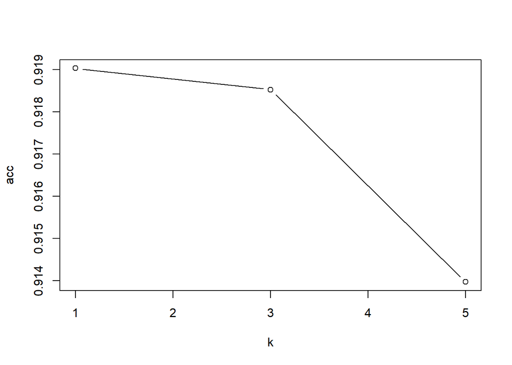

```r
#knn
knn_k_search<-function(dtm,k_v){
  cv_index<-createFolds(dtm$category,k=4)
  train_x<-dtm[unlist(cv_index[-1]),]%>%select(-category)
  train_y<-dtm[unlist(cv_index[-1]),]%>%select(category)
  valid_x<-dtm[unlist(cv_index[1]),]%>%select(-category)
  valid_y<-dtm[unlist(cv_index[1]),]%>%select(category)
  k<-c()
  acc<-c()
  for (i in k_v){
    pred<-knn(train_x, valid_x, train_y[,1],k=i)
    k<-c(k,i)
    acc<-c(acc,(confusionMatrix(pred,valid_y[,1])[[3]][1]))}
  df_acc<-data.frame(k=k,acc=acc)
  plot(df_acc,type="b")
}

knn_k_search(all_DTM,c(1,3,5))
```

```r
#knn cross-validation
knn_cv<-function(dtm,k=1,n=5){
  cv_index<-createFolds(dtm$category,k=n)
  knn_pred<<-rep(0,nrow(dtm))
  for (i in 1:n){
    train_x<-dtm[unlist(cv_index[-i]),]%>%select(-category)
    train_y<-dtm[unlist(cv_index[-i]),]%>%select(category)
    valid_x<-dtm[unlist(cv_index[i]),]%>%select(-category)
    valid_y<-dtm[unlist(cv_index[i]),]%>%select(category)
    pred<-knn(train_x, valid_x, train_y[,1],k=k)
    knn_pred[unlist(cv_index[i])]<<-as.character(pred)}
  return(head(knn_pred,50))
}

knn_cv(all_DTM,k=1,n=5) #k=1이 제일 좋은 성능
```

```
##  [1] "trade"    "sugar"    "earn"     "earn"     "earn"     "acq"
##  [7] "earn"     "acq"      "earn"     "earn"     "trade"    "trade"
## [13] "trade"    "acq"      "money.fx" "acq"      "earn"     "trade"
## [19] "acq"      "acq"      "earn"     "trade"    "acq"      "trade"
## [25] "trade"    "earn"     "earn"     "acq"      "earn"     "earn"
## [31] "acq"      "acq"      "acq"      "earn"     "sugar"    "earn"
## [37] "sugar"    "earn"     "earn"     "earn"     "earn"     "earn"
## [43] "earn"     "earn"     "earn"     "earn"     "earn"     "acq"
## [49] "earn"     "acq"
```

```r
sum(knn_pred==category$category)/nrow(category)
```

```
## [1] 0.9303325
```

```r
#confusion matrix
confusionMatrix(as.factor(knn_pred),category$category)
```

```
## Confusion Matrix and Statistics
##
##           Reference
## Prediction  acq coffee crude earn interest money.fx ship sugar trade
##   acq      2148      4    31  122        5        6    1    35    22
##   coffee      2    105     2    1        0        1    0     1     5
##   crude       7      0   301    3        0        5    0    11     9
##   earn       72      3    13 3746        4        5    1     6     7
##   interest    7      0     5    6      230       34    7     5     6
##   money.fx    3      0     3    3       25      240    4     4     8
##   ship        0      0     0    3        4        7  129     0     5
##   sugar       2      0     4    0        0        1    0    76     1
##   trade       4      0     4    1        2        5    1     3   383
##
## Overall Statistics
##
##                Accuracy : 0.9303
##                  95% CI : (0.9245, 0.9358)
##     No Information Rate : 0.4912
##     P-Value [Acc > NIR] : < 0.00000000000000022
##
##                   Kappa : 0.8955
##
##  Mcnemar's Test P-Value : NA
##
## Statistics by Class:
##
##                      Class: acq Class: coffee Class: crude Class: earn
## Sensitivity              0.9568       0.93750      0.82920      0.9642
## Specificity              0.9601       0.99846      0.99536      0.9724
## Pos Pred Value           0.9048       0.89744      0.89583      0.9712
## Neg Pred Value           0.9825       0.99910      0.99181      0.9657
## Prevalence               0.2839       0.01416      0.04590      0.4912
## Detection Rate           0.2716       0.01328      0.03806      0.4736
## Detection Prevalence     0.3002       0.01479      0.04248      0.4877
## Balanced Accuracy        0.9584       0.96798      0.91228      0.9683
##                      Class: interest Class: money.fx Class: ship Class: sugar
## Sensitivity                  0.85185         0.78947     0.90210     0.539007
## Specificity                  0.99084         0.99343     0.99755     0.998970
## Pos Pred Value               0.76667         0.82759     0.87162     0.904762
## Neg Pred Value               0.99474         0.99160     0.99820     0.991693
## Prevalence                   0.03414         0.03844     0.01808     0.017828
## Detection Rate               0.02908         0.03035     0.01631     0.009609
## Detection Prevalence         0.03793         0.03667     0.01871     0.010621
## Balanced Accuracy            0.92134         0.89145     0.94983     0.768989
##                      Class: trade
## Sensitivity               0.85874
## Specificity               0.99732
## Pos Pred Value            0.95037
## Neg Pred Value            0.99161
## Prevalence                0.05639
## Detection Rate            0.04843
## Detection Prevalence      0.05095
## Balanced Accuracy         0.92803
```

- knn을 훈련시키기 위해서 최적의 k를 찾는 함수 생성.
- n-fold cross validation knn 함수 생성.
- 최적의 k는 1임을 알 수 있음.
- k=1로 5fold cross validation 적용.

### Randomforest

```r
cv_rf<-function(dtm,ntree=100,n=5){
    rf_pred<<-rep(9,length(category$category))
    cv_index<-createFolds(dtm$category,k=n)
    for (i in 1:n){
      train<-dtm[unlist(cv_index[-i]),]
      valid_x<-dtm[unlist(cv_index[i]),]%>%select(-category)
      valid_y<-dtm[unlist(cv_index[i]),]%>%select(category)

      rf<-randomForest(category~.,train,ntree=ntree)
      pred<-predict(rf, valid_x)
      rf_pred[unlist(cv_index[i])]<<-as.character(pred) }
    return(head(rf_pred,50))
}

cv_rf(all_DTM,500,5)
```

```
##  [1] "trade" "sugar" "acq"   "earn"  "earn"  "acq"   "earn"  "earn"  "earn"
## [10] "earn"  "trade" "trade" "trade" "acq"   "acq"   "acq"   "earn"  "trade"
## [19] "acq"   "acq"   "earn"  "trade" "acq"   "trade" "trade" "earn"  "earn"
## [28] "acq"   "earn"  "earn"  "acq"   "acq"   "acq"   "earn"  "sugar" "earn"
## [37] "sugar" "earn"  "earn"  "earn"  "earn"  "earn"  "earn"  "earn"  "earn"
## [46] "earn"  "earn"  "acq"   "earn"  "acq"
```

```r
#성능 확인
sum(rf_pred==as.character(category$category))/nrow(category)
```

```
## [1] 0.9562524
```

```r
#confusion matrix
confusionMatrix(as.factor(rf_pred),category$category)
```

```
## Confusion Matrix and Statistics
##
##           Reference
## Prediction  acq coffee crude earn interest money.fx ship sugar trade
##   acq      2215      2    27   87        9       20    1    36    10
##   coffee      0    108     0    0        0        0    0     0     0
##   crude       2      0   324    2        0        0    0     3     1
##   earn       25      0     7 3796        3        7    4     3     1
##   interest    0      0     0    0      225       25    4     0     1
##   money.fx    0      0     0    0       25      239    2     0     3
##   ship        0      0     0    0        4        4  131     0     0
##   sugar       0      0     3    0        0        0    0    96     1
##   trade       3      2     2    0        4        9    1     3   429
##
## Overall Statistics
##
##                Accuracy : 0.9563
##                  95% CI : (0.9515, 0.9607)
##     No Information Rate : 0.4912
##     P-Value [Acc > NIR] : < 0.00000000000000022
##
##                   Kappa : 0.9344
##
##  Mcnemar's Test P-Value : NA
##
## Statistics by Class:
##
##                      Class: acq Class: coffee Class: crude Class: earn
## Sensitivity              0.9866       0.96429      0.89256      0.9771
## Specificity              0.9661       1.00000      0.99894      0.9876
## Pos Pred Value           0.9202       1.00000      0.97590      0.9870
## Neg Pred Value           0.9945       0.99949      0.99485      0.9781
## Prevalence               0.2839       0.01416      0.04590      0.4912
## Detection Rate           0.2801       0.01366      0.04097      0.4800
## Detection Prevalence     0.3043       0.01366      0.04198      0.4863
## Balanced Accuracy        0.9764       0.98214      0.94575      0.9823
##                      Class: interest Class: money.fx Class: ship Class: sugar
## Sensitivity                  0.83333         0.78618     0.91608      0.68085
## Specificity                  0.99607         0.99606     0.99897      0.99949
## Pos Pred Value               0.88235         0.88848     0.94245      0.96000
## Neg Pred Value               0.99412         0.99149     0.99846      0.99424
## Prevalence                   0.03414         0.03844     0.01808      0.01783
## Detection Rate               0.02845         0.03022     0.01656      0.01214
## Detection Prevalence         0.03224         0.03401     0.01757      0.01264
## Balanced Accuracy            0.91470         0.89112     0.95753      0.84017
##                      Class: trade
## Sensitivity               0.96188
## Specificity               0.99678
## Pos Pred Value            0.94702
## Neg Pred Value            0.99772
## Prevalence                0.05639
## Detection Rate            0.05424
## Detection Prevalence      0.05728
## Balanced Accuracy         0.97933
```

- k-fold cross validation randomforest 함수 생성
- 500개의 decision tree를 생성하여 bagging
- 5-fold cross validation
- 상당히 좋은 성능

### NaiveBayes

```r
nb_cv<-function(dtm,n=5){
  cv_index<-createFolds(dtm$category,k=n)
  nb_pred<<-rep(0,nrow(dtm))
  cat_DTM<-as.data.frame(lapply(X = dtm%>%select(-category),FUN = as.factor))
  for (i in 1:n){
    train_x<-cat_DTM[unlist(cv_index[-i]),]
    train_y<-category[unlist(cv_index[-i]),]$category
    valid_x<-cat_DTM[unlist(cv_index[i]),]
    valid_y<-category[unlist(cv_index[i]),]$category
    nb <- naiveBayes(train_x,  train_y)
    pred<-predict(nb,valid_x)
    nb_pred[unlist(cv_index[i])]<<-as.character(pred)}
  return(head(nb_pred,50))
}

nb_cv(all_DTM,5)
```

```
##  [1] "trade" "sugar" "trade" "acq"   "earn"  "acq"   "acq"   "crude" "earn"
## [10] "earn"  "trade" "trade" "acq"   "acq"   "earn"  "acq"   "earn"  "trade"
## [19] "acq"   "trade" "acq"   "trade" "acq"   "sugar" "trade" "acq"   "earn"
## [28] "acq"   "earn"  "earn"  "acq"   "acq"   "acq"   "earn"  "sugar" "earn"
## [37] "sugar" "earn"  "earn"  "earn"  "earn"  "earn"  "earn"  "earn"  "earn"
## [46] "earn"  "earn"  "acq"   "earn"  "trade"
```

```r
#성능 확인
sum(nb_pred==category$category)/nrow(category)
```

```
## [1] 0.8733089
```

```r
#confusion matrix
confusionMatrix(as.factor(nb_pred),category$category)
```

```
## Confusion Matrix and Statistics
##
##           Reference
## Prediction  acq coffee crude earn interest money.fx ship sugar trade
##   acq      2076      2    15  262        2        1    0    13    19
##   coffee      0     83     0    0        0        0    0     0     0
##   crude      17      2   286   73        1        0    0     3     5
##   earn       93     10    37 3475        6       14    0     0    10
##   interest    1      1     0    3      202       37    6     1    10
##   money.fx    5      0     1   13       33      203    6     0    14
##   ship        6      3     3    1       16       30  130     2    45
##   sugar       3      5    11    0        1        0    0   116     7
##   trade      44      6    10   58        9       19    1     6   336
##
## Overall Statistics
##
##                Accuracy : 0.8733
##                  95% CI : (0.8658, 0.8806)
##     No Information Rate : 0.4912
##     P-Value [Acc > NIR] : < 0.00000000000000022
##
##                   Kappa : 0.8133
##
##  Mcnemar's Test P-Value : NA
##
## Statistics by Class:
##
##                      Class: acq Class: coffee Class: crude Class: earn
## Sensitivity              0.9247       0.74107      0.78788      0.8945
## Specificity              0.9446       1.00000      0.98662      0.9578
## Pos Pred Value           0.8686       1.00000      0.73902      0.9534
## Neg Pred Value           0.9694       0.99629      0.98976      0.9038
## Prevalence               0.2839       0.01416      0.04590      0.4912
## Detection Rate           0.2625       0.01049      0.03616      0.4394
## Detection Prevalence     0.3022       0.01049      0.04893      0.4609
## Balanced Accuracy        0.9346       0.87054      0.88725      0.9261
##                      Class: interest Class: money.fx Class: ship Class: sugar
## Sensitivity                  0.74815         0.66776     0.90909      0.82270
## Specificity                  0.99228         0.99053     0.98635      0.99652
## Pos Pred Value               0.77395         0.73818     0.55085      0.81119
## Neg Pred Value               0.99111         0.98677     0.99831      0.99678
## Prevalence                   0.03414         0.03844     0.01808      0.01783
## Detection Rate               0.02554         0.02567     0.01644      0.01467
## Detection Prevalence         0.03300         0.03477     0.02984      0.01808
## Balanced Accuracy            0.87021         0.82915     0.94772      0.90961
##                      Class: trade
## Sensitivity               0.75336
## Specificity               0.97950
## Pos Pred Value            0.68712
## Neg Pred Value            0.98518
## Prevalence                0.05639
## Detection Rate            0.04248
## Detection Prevalence      0.06183
## Balanced Accuracy         0.86643
```

- 나이브 베이즈는 범주형 변수를 취급하기때문에 모든 단어를 범주형으로 변환
- cross validation naive bayes 함수 정의
- 저조한 성능

### Ensemble - stacking (meta learner : XGBoost)

```r
stk_df<-data.frame(knn_pred=knn_pred,
                   rf_pred=rf_pred,
                   nb_pred=nb_pred,
                   y=category$category) %>% data.matrix

xgb<-xgb.cv(data = stk_df[,c(1,2,3)], label = stk_df[,4]-1, num_class=9, nfold=5,
            nrounds = 100, early_stopping_rounds = 10, objective = "multi:softprob",
            eval_metric = 'merror', verbose = 10, prediction = T)
```

[output not shown]

```r
#최종 classification accuracy
1-xgb$evaluation_log$test_merror_mean[xgb$best_iteration]
```

```
## [1] 0.9589082
```

- 성능 향상을 위해 지금까지 학습한 모델들을 ensemble(stacking)
- knn, randomforest, naivebayes의 결과값을 종합해 XGBoost로 예측
- stacking으로 인해 최고 성능 기록
- 최종모델